# A Bayesian Multilevel Model for the Psychometric Function

November, 2020

## Introduction

- Began my Masters by taking *Intro to Statistical Computing* with Dr. Schissler
- Asked if there were any projects that I could become involved with
- Had the opportunity to work with psychometric data provided by Dr. Fang
- Initially started as a data cleaning project that turned into modeling and analysis
- While cleaning the data, I had to learn the details of the experimental setup and the deeper theory

## What are psychometrics?

- Psychometric experiments allow us to examine the response between the world around us and our inward perceptions
- Biological and contextual factors influence the integration/segregation of multisensory signals
- A psychometric function relates an observer’s performance to an independent variable
- When the temporal delay between stimuli grows large enough, the brain segregates the two signals and the temporal order can be determined

## Some more background

- The range of temporal delays for which sensory signals are integrated into a global percept is called the temporal binding window
- Perceptual synchrony is the temporal delay between two signals at which an observer is unsure about their temporal order
- The ability to discriminate the timing of multiple sensory signals is referred to as temporal sensitivity
- A deficit in temporal sensitivity may lead to a widening of the temporal binding window

## Temporal order judgment tasks

- **Audiovisual** task asks observers if they perceived an audio stimulus before a visual
- **Visual** task asks observers if the right visual stimulus came before the left
- **Duration** task asks observers if lower a circle on a screen was presented longer than an upper circle
- **Sensorimotor** task asks observers if a visual stimulus on a screen came before they pressed a button

| soa | response | sid | task | trial | age_group | age | sex |
| --- | --- | --- | --- | --- | --- | --- | --- |
| -350 | 0 | O-m-BC | audiovisual | pre | older_adult | 70 | M |
| -200 | 0 | M-m-SJ | duration | post1 | middle_age | 48 | M |
| 28 | 1 | O-f-KK | sensorimotor | pre | older_adult | 66 | F |
| 275 | 1 | O-f-MW | visual | post1 | older_adult | 69 | F |

*I use “positive” and “negative” to refer to “yes” and “no” responses respectively*

## Temporal recalibration

- Perceptual synchrony and temporal sensitivity can be modified through a baseline understanding
- To perceive events as simultaneous, our brains adjust for differences in temporal delays of transmission
- The perception of simultaneity can be modified by repeatedly presenting the stimuli at fixed time separations (called an adapter stimulus) to an observer
- This repetition of presenting the adapter stimulus is called temporal recalibration

## Experimental motivation

- Does age have an affect on the temporal binding window?
- Does temporal recalibration affect the temporal binding window?
- The temporal binding window is described by two measures
  - **Point of subjective simultaneity** (PSS) which is a measure of perceptual synchrony
  - **Just noticeable difference** (JND) which is the smallest lapse in time so that a temporal order can just be determined

## The psychometric function

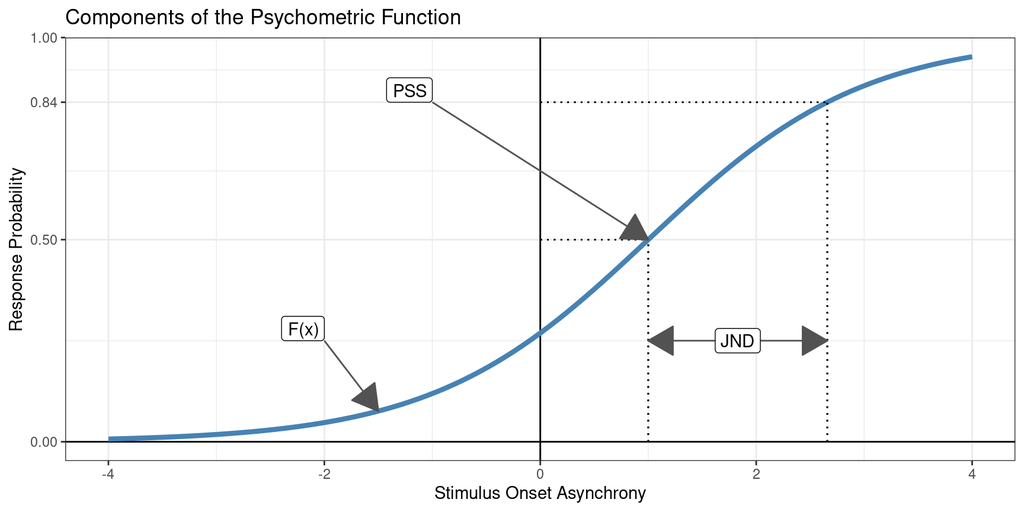

\[ \begin{align*} \textrm{PSS} &= \textit{point of subjective simultaneity} \\ \textrm{JND} &= \textit{just noticable difference} \end{align*} \]

## Three ways to visualize the observed data

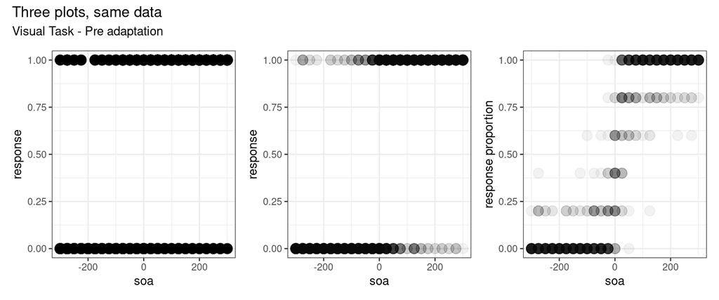

- Transparency better shows the density of “positive” responses at different temporal delays
- Can aggregate repeated measures for temporal delays into Binomial counts
- Proportion can be derived from aggregated Binomial counts

## Data quirks

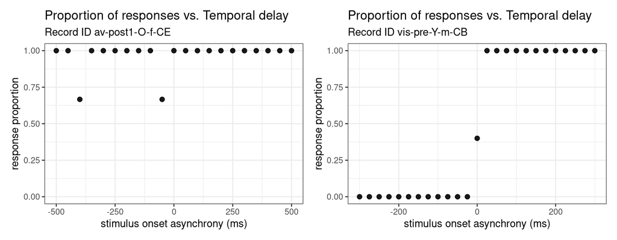

- (Left) record for `av-post1-O-f-CE` removed from data set
- (Right) some subjects in the visual task have exceptional performance (approaching perfect separation)

## Modeling the Psychometric Function

## Why not use a simple GLM?

```r
glm_subject_level <- glm(response ~ 0 + sid + sid:soa,
  family = binomial("logit"), data = visual,
  subset = trial %in% c("pre", "post1"))
```

| sid | (Intercept) | soa | pss (ms) | jnd (ms) |
| --- | --- | --- | --- | --- |
| M-m-BT | 0.511 | 0.648 | -0.789 | 2.560 |
| Y-m-CB | 0.000 | 0.644 | 0.000 | 2.577 |

- Easy to use and fit in `R`
- Necessary to drop one of the categorical levels
- Estimating confidence intervals for psychometric properties requires bootstrap methods
- Near perfect separation results in unreliably large standard errors

## Mixed effects models

```r
library(lme4) # linear mixed effects
glmer_subject_level <- glmer(
  response ~ 1 + soa + (1 + soa | sid),
  family = binomial("logit"), data = visual,
  subset = trial %in% c("pre", "post1"))
```

| sid | (Intercept) | soa | pss (ms) | jnd (ms) |
| --- | --- | --- | --- | --- |
| M-m-BT | -0.311 | 0.075 | 4.136 | 22.059 |
| Y-m-CB | -0.385 | 0.076 | 5.043 | 21.713 |

- Can model the fixed effects shared across all groups and the group (random) effects
- Levels with less information are shrunk towards the fixed parameter estimate
- More “reasonable” estimates of the just noticeable difference
- Cannot incorporate prior information
- Not flexible enough to model more complex psychometric features like lapse rates

## Enter Bayesian statistics

\[ \pi(\theta | data) = \frac{\pi(data | \theta) \pi(\theta)}{\int_\Omega \pi(data | \theta) \pi(\theta) d\theta} \]

- Bayes’ Theorem is a simple rearranging of conditional probability
  - \(P(A|B) = P(A \cap B) / P(B) = P(B|A) \cdot P(A)/P(B)\)
- The prior \(\pi(\theta)\) is some distribution over the parameter space
- The likelihood \(\pi(data | \theta)\) is the probability of an outcome in the sample space given a value in the parameter space
- The denominator is the average likelihood of the data over the parameter space
- The posterior \(\pi(\theta | data)\) is our updated belief of the distribution of the parameter

## Easy in theory, difficult in practice

\[ \pi(\theta | data) = \frac{\pi(data | \theta) \pi(\theta)}{\int_\Omega \pi(data | \theta) \pi(\theta) d\theta} \]

- The denominator is a constant scale factor that ensures \(\pi(\theta|data)\) is a proper probability distribution
  - We often say that the posterior is proportional to the prior times the likelihood: \(\quad \pi(\theta | data) \propto \pi(\theta) \times \pi(data | \theta)\)
- Often the integral in the denominator is complex or of a high dimension
- A solution is to use **Markov Chain Monte Carlo** (MCMC) simulations to draw samples directly from the posterior distribution

## Hamiltonian Monte Carlo

- Markov Chain Monte Carlo constructs a sequence of proposal points from a target distribution
  - Points are accepted or rejected based off of some criterion
- **Hamiltonian Monte Carlo** (HMC) tracks the position of a “particle” following frictionless Hamiltonian dynamics
  - The particle is imparted with a random direction and kinetic energy
  - Effective sampling of high-dimensional probability spaces
  - Has greatly reduced pointwise autocorrelation compared to simpler MCMC
  - Requires evaluating the gradient at each step

[Click me for a demo](http://chi-feng.github.io/mcmc-demo/app.html?algorithm=HamiltonianMC&target=donut)

## Say hello to Stan

- `Stan` is a state-of-the-art platform for statistical modeling
- Gives full Bayesian statistical inference with MCMC sampling
- Utilizes no-U-turn-sampling (NUTS) variant of Hamiltonian Monte Carlo
- Has interfaces to popular programming languages such as `R`, `Python`, and `Julia`
- Provides differentiable probability functions and linear algebra

## Building a Model for the Psychometric Function

### Using a Principled Bayesian Workflow

## What is a Principled Bayesian Workflow?

- A method of employing domain expertise and statistical knowledge to iteratively build a statistical model
- Satisfies the constraints and goals set forth by the researcher
- Four questions to evaluate a model by
  - Domain Expertise Consistency
  - Computational Faithfulness
  - Inferential Adequacy
  - Model Adequacy

## The Workflow in Brief

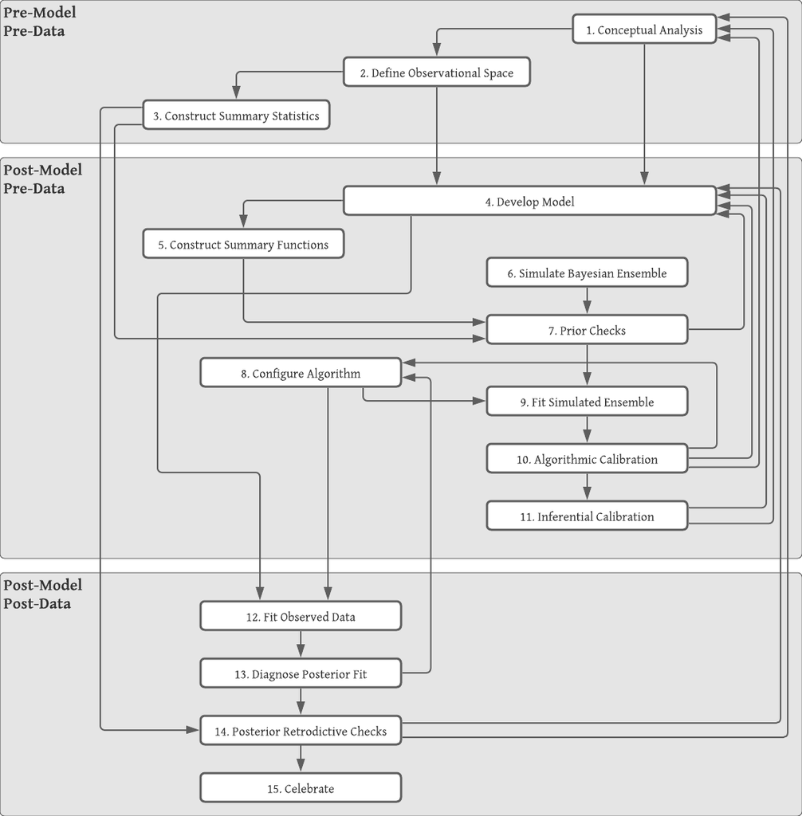

- Pre-model, pre-data
  - conceptual analysis
  - observation space
- Post-model, pre-data
  - Turn conceptual analysis and observational space into a mathematical model
  - Check prior-predictive distribution against domain knowledge
- Post-model, post-data
  - Fit the observed data to the model
  - Perform posterior predictive checks
- Iterate

## Pre-workflow considerations

- Psychometric properties inform modeling choices
  - Point of subjective simultaneity and just noticeable difference are estimated from the psychometric function
  - We have prior information about the PSS and JND
- We have control over:
  - Choice of psychometric function
  - Choice of linear parameterization
  - Choice of priors

## Choice of psychometric function

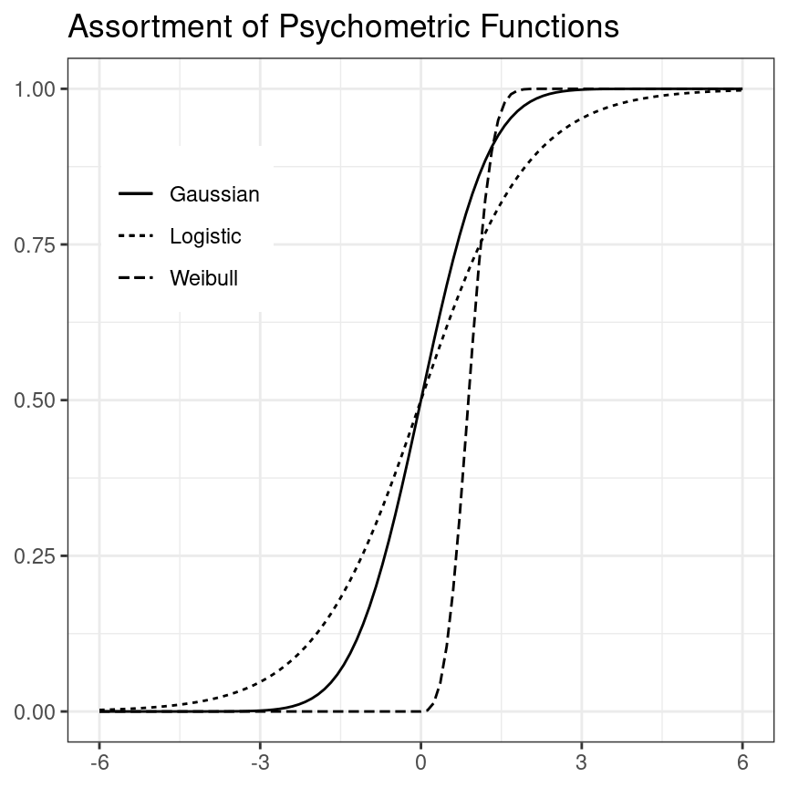

- Logistic and Gaussian have no skewness
- Gaussian puts predictor on standard (probit) scale
- Logistic puts predictor on log-odds (logit) scale
- Logistic is the “canonical” choice for Binomial regression
- We use the logistic function:

\[ F(\theta) = \frac{1}{1 + \exp(-\theta)} \]

## Choice of linear parameterization

The **point of subjective simultaneity** and **just noticeable difference** are defined as

\[ \begin{align*} pss &:= F^{-1}(0.5; \alpha, \beta) \\ jnd &:= F^{-1}(0.84; \alpha, \beta) - F^{-1}(0.5; \alpha, \beta) \end{align*} \]

“Slope-intercept” linear parameterization

\[ \begin{equation*} \theta = \alpha + \beta x \Longrightarrow \begin{split} pss &= -\frac{\alpha}{\beta} \\ jnd &= \frac{\mathrm{logit}(0.84)}{\beta} \end{split} \end{equation*} \]

“Slope-location” linear parameterization

\[ \begin{equation*} \theta = \beta (x - \alpha) \Longrightarrow \begin{split} pss &= \alpha \\ jnd &= \frac{\mathrm{logit}(0.84)}{\beta} \end{split} \end{equation*} \]

## Selecting priors - Point of subjective simultaneity

- The point of subjective simultaneity can be either positive or negative
- Some studies suggest that the separation between stimuli need to be as little as 20ms for subjects to be able to determine temporal order
- Other studies suggest that our brains can detect temporal differences as small as 30ms
- We should be skeptical of PSS estimates larger than say 150ms in absolute value
- \[pss \sim \mathcal{N}(0, 0.06^2) \Longleftrightarrow \alpha \sim \mathcal{N}(0, 0.06^2)\]

## Selecting priors - Just noticeable difference

- It is impossible that a properly conducted block would result in a just noticeable difference less than 0
- Also unlikely that the just noticeable difference would be more than a second
- Some studies show that an input lag as small as 100ms can impair a person’s typing ability
- The log-normal distribution is a convenient choice for the just noticeable difference
- Choose prior so that \(median[\textrm{JND}] \approx 0.100\) and \(P(\textrm{JND} < 1) \approx 0.99\)
  - \[jnd \sim \mathrm{Lognormal}(-2.3, 1^2)\]
  - \[\beta = \frac{\mathrm{logit}(0.84)}{jnd} \Longleftrightarrow \beta \sim \mathrm{Lognormal}(2.8, 1^2)\]

## Defining the observational space

- The response that subjects give during a temporal order judgment task is recorded as a zero or a one
  - \(y_i \in \lbrace 0, 1\rbrace\)
- If the stimulus onset asynchronies (SOAs) are fixed then we have repeated measurements for each SOA and the responses can be aggregated into Binomial counts
  - \(k_i, n_i \in \mathbb{Z}_0^+, k_i \le n_i\)
  - \(k_i \sim \mathrm{Binomial}(n_i, p_i)\)

## Iteration 1 - baseline model

In the language of math

\[ \begin{equation*} \begin{split} k_i &\sim \mathrm{Binomial}(n_i, p_i) \\ \mathrm{logit}(p_i) &= \beta \cdot (x_i - \alpha) \\ \alpha &\sim \mathcal{N}(0, 0.06^2) \\ \beta &\sim \mathrm{Lognormal}(3, 1^2) \end{split} \end{equation*} \]

In the language of `Stan`

```
model {
  vector[N] p = beta * (x - alpha);
  alpha ~ normal(0, 0.06);
  beta ~ lognormal(3.0, 1.0);
  k ~ binomial_logit(n, p);
}
```

## Prior distribution of psychometric functions

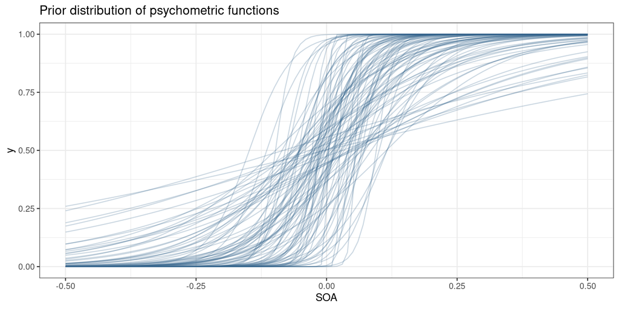

## Iteration 2 - adding age and block categories

Three ways to add a categorical variable

\[ \begin{equation} \begin{split} \mu_\alpha &= \alpha_{trt[i]} \\ \alpha_{trt} &\sim \mathcal{N}(0, 0.06^2) \end{split} \qquad \begin{split} \mu_\alpha &= \alpha_{trt[i]} \\ \alpha &\sim \mathcal{N}(0, 0.06^2) \\ \alpha_{trt} &\sim \mathcal{N}(\alpha, \sigma_{trt}^2) \\ \sigma_{trt} &\sim \pi_{\sigma} \end{split} \qquad \begin{split} \mu_\alpha &= \alpha + \alpha_{trt[i]} \\ \alpha &\sim \mathcal{N}(0, 0.06^2) \\ \alpha_{trt} &\sim \mathcal{N}(0, \sigma_{trt}^2) \\ \sigma_{trt} &\sim \pi_{\sigma} \end{split} \end{equation} \]

- (Left) Categorical variable replaces the intercept so each level explicitly gets its own intercept
- (Center) Each categorical variable is modeled as having the same mean and standard deviation that is learned from the data (centered multilevel)
- (Right) Same as center, but using the non-centered parameterization
  - Most convenient when adding multiple categorical variables

## Using the non-centered log-normal parameterization

\[ \begin{align*} X &\sim \mathcal{N}(3, 1^2) \\ Y &= \exp\left(X\right) \Longleftrightarrow Y \sim \mathrm{Lognormal(3, 1^2)} \end{align*} \]

Adding categorical variables to the slope term is more tractable

\[ \begin{equation} \begin{split} k_i &\sim \mathrm{Binomial}(n_i, p_i) \\ \mathrm{logit}(p_i) &= \exp(\mu_\beta) (x_i - \mu_\alpha) \\ \mu_\alpha &= \alpha + \alpha_{trt[i]} + \alpha_{G[i]} \\ \mu_\beta &= \beta + \beta_{trt[i]} + \beta_{G[i]} \\ \end{split} \end{equation} \]

## Iteration 2 - Checking the posterior

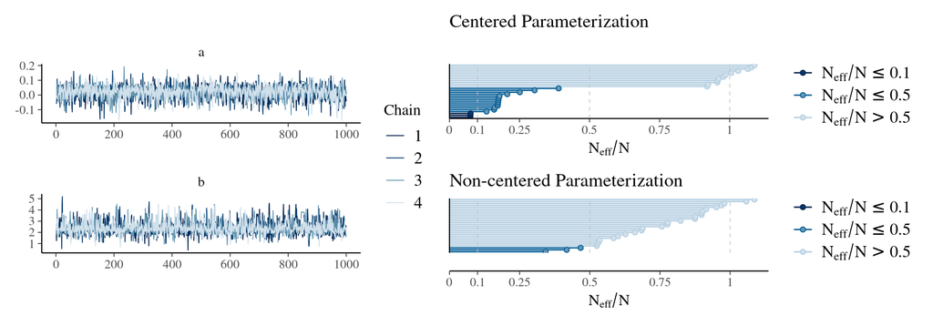

- (Left) trace plot shows that Markov chains are “healthy”
- (Right) Autocorrelation between samples reduces the effective sample size
  - Non-centered parameterization allows for more efficient exploration of the posterior

## Iteration 3 - modeling age-block interactions

- There is a problem with the previous model
  - It measures the average difference in blocks, and the average difference in age groups
  - Does not consider any interaction between the two
  - Model assumes that temporal recalibration affects all age groups the same
- Modeling interactions between categorical variables by creating a new categorical variable
  - If \(G\) has levels \(\{\textrm{young}, \textrm{middle}, \textrm{older}\}\) and \(B\) has levels \(\{\textrm{pre}, \textrm{post}\}\), then the interaction variable \(C=G\times B\) will have levels

\[ G = \begin{bmatrix} \textrm{young} \\ \textrm{middle} \\ \textrm{older} \end{bmatrix}, B = \begin{bmatrix} \textrm{pre} \\ \textrm{post} \end{bmatrix}\Longrightarrow G\times B = \begin{bmatrix} \textrm{young-pre} & \textrm{young-post} \\ \textrm{middle-pre} & \textrm{middle-post} \\ \textrm{older-pre} & \textrm{older-post} \end{bmatrix} \]

## Iteration 4 - incorporating a lapse rate

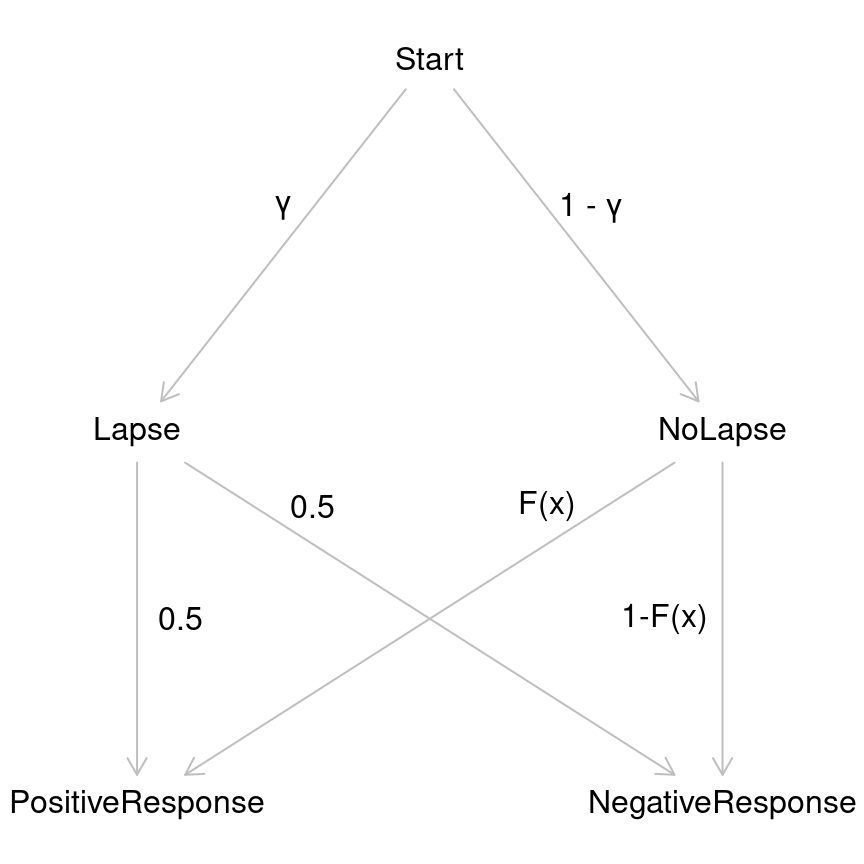

- The subject either experiences a lapse in judgment with probability \(\gamma\) or they do not
- If there is no lapse, they will give a positive response with probability \(\pi=F(x)\)
- If there is a lapse in judgment, then it is assumed that they will respond randomly
- The probability of a positive response is the sum of the two paths:

\[ \begin{align*} \mathrm{P}(\textrm{positive}) &= \mathrm{P}(\textrm{lapse}) \cdot \mathrm{P}(\textrm{positive} | \textrm{lapse}) \\ &\quad + \mathrm{P}(\textrm{no lapse}) \cdot \mathrm{P}(\textrm{positive} | \textrm{no lapse}) \\ &= \frac{1}{2} \gamma + (1 - \gamma) \cdot F(x) \end{align*} \]

## Chart of a lapse rate model

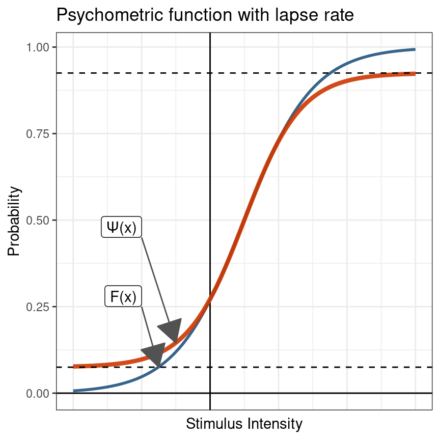

\[ \begin{equation} \begin{split} k_i &\sim \mathrm{Binomial}(n_i, p_i) \\ p_i &= \lambda + (1 - 2\lambda)\cdot F\left(\exp(\mu_\beta) (x_i - \mu_\alpha)\right) \\ \mu_\alpha &= \alpha + \alpha_{G[i] \times trt[i]} \\ \mu_\beta &= \beta + \beta_{G[i] \times trt[i]} \\ \end{split} \end{equation} \]

```
model {
  vector[N] p;
  for (i in 1:N) {
    real mu_b = b + bGT[G[i], trt[i]];
    real mu_a = a + aGT[G[i], trt[i]];
    p[i] = lG[G[i]] + (1 - 2*lG[G[i]]) *
            inv_logit(exp(mu_b) * (x[i] - mu_a));
  }
  k ~ binomial(n, p);
}
```

## Result of modeling a lapse rate

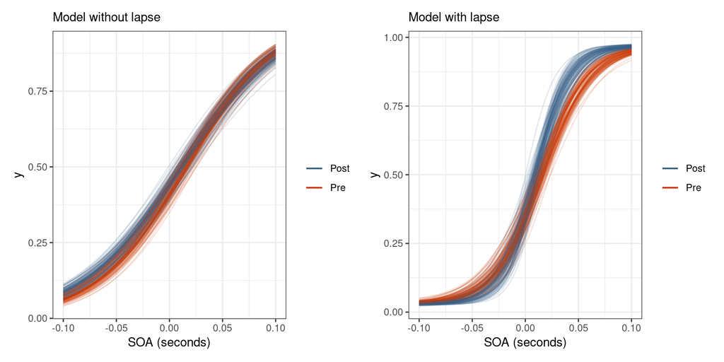

## Iteration 5 - adding subject-level parameters

\[ \begin{equation*} \begin{split} k_i &\sim \mathrm{Binomial}(n_i, p_i) \\ p_i &= \lambda_{G[i]} + (1 - 2\lambda_{G[i]})\exp(\mu_\beta) (x_i - \mu_\alpha) \\ \mu_\alpha &= \alpha + \alpha_{G[i], trt[i]} + \alpha_{S[i]} \\ \mu_\beta &= \beta + \beta_{G[i], trt[i]} + \beta_{S[i]} \\ \lambda_{G} &\sim \mathrm{Beta}(4, 96) \\ \hat{\alpha}, \hat{\alpha}_{G\times trt}, \hat{\alpha}_{S} &\sim \mathcal{N}(0, 1^2) \\ \hat{\beta}, \hat{\beta}_{G\times trt}, \hat{\beta}_{S} &\sim \mathcal{N}(0, 1^2) \\ \hat{\sigma}_{G\times trt}, \hat{\gamma}_{G\times trt}, \hat{\tau}_{S}, \hat{\nu}_{S} &\sim \mathcal{U}(0, \pi/2) \\ \end{split} \qquad \begin{split} \alpha &= 0.06 \cdot \hat{\alpha} \\ \alpha_{G\times trt} &= \sigma_{G\times trt} \cdot \hat{\alpha}_{trt} \\ \alpha_{S} &= \tau_{S} \cdot \hat{\alpha}_{S} \\ \sigma_{G \times trt} &= \tan(\hat{\sigma}_{G \times trt}) \\ \tau_{S} &= \tan(\hat{\tau}_{S}) \\ \beta &= 3 + 1 \cdot \hat{\beta} \\ \beta_{G\times trt} &= \gamma_{G\times trt} \cdot \hat{\beta}_{G\times trt} \\ \beta_{S} &= \nu_{S} \cdot \hat{\beta}_{S} \\ \gamma_{G\times trt} &= \tan(\hat{\gamma}_{G\times trt}) \\ \nu_{S} &= \tan(\hat{\nu}_{S}) \end{split} \end{equation*} \]

## Model Assessment

- Domain Expertise Consistency
  - The model does not predict anything that conflicts with domain expertise
- Computational Faithfulness
  - Posterior samples are reliable as determined by posterior checks
    - Trace plots, split \(\hat{R}\), \(N_{\textrm{eff}}/N\) ratio, divergent transitions
- Inferential Adequacy
  - Modeling age and block interactions allows us to answer questions about age and temporal recalibration
- Model Adequacy
  - Modeling a lapse rate is more true to the data generating process, and improves predictive performance

## Psychometric Inferences

## Perceptual synchrony

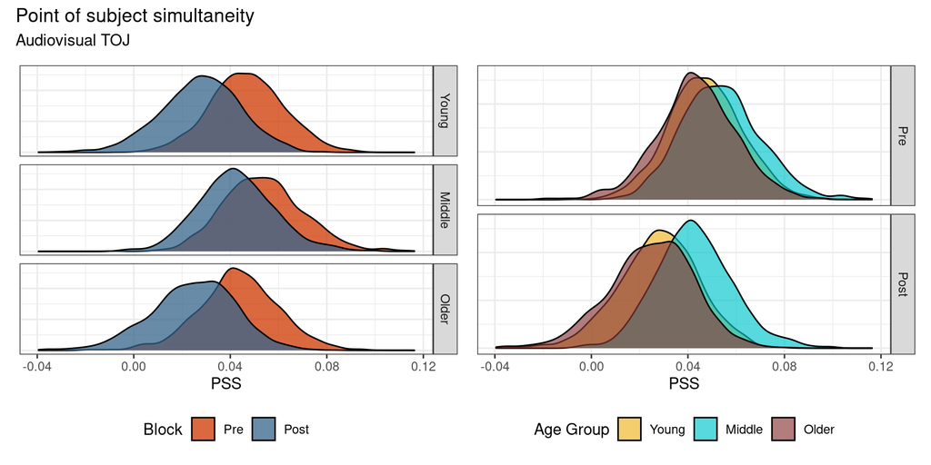

## Temporal sensitivity

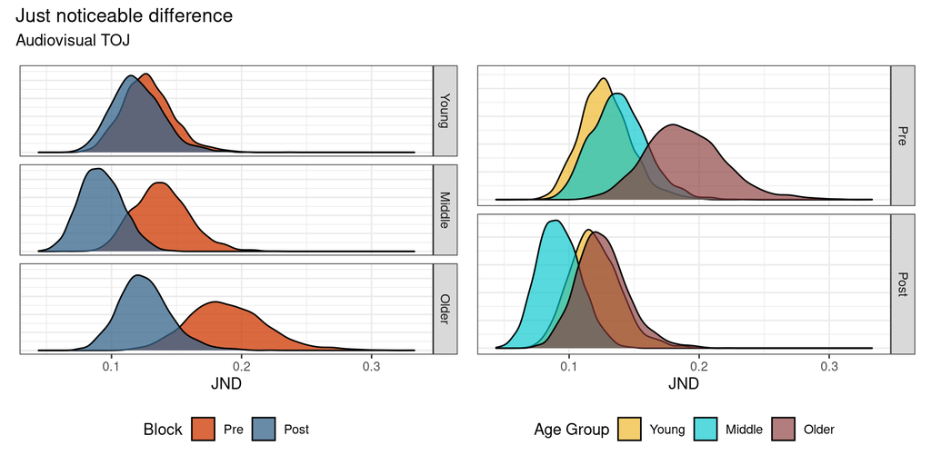

## Lapse rates

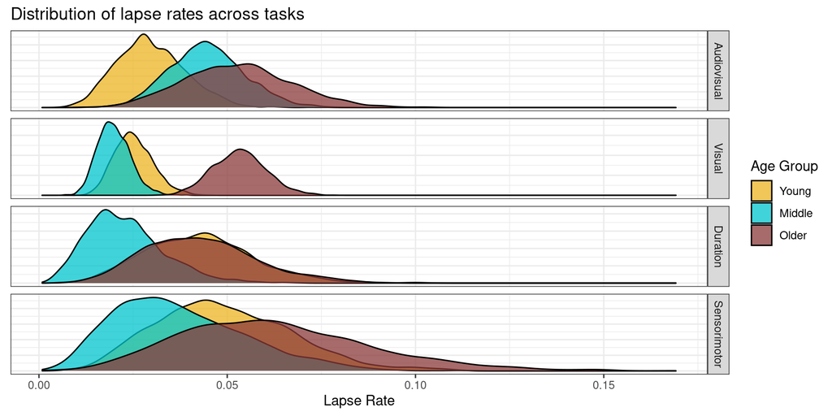

## Subject-specific examples

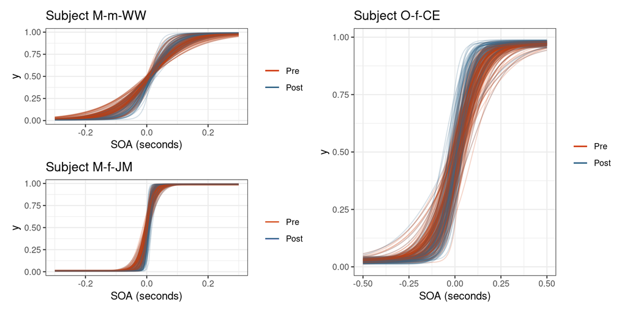

## Improving psychometric experiments

- The results here are based on small-scale preliminary data
- There is an inherent difficulty for the different tasks
  - Visual < Audiovisual < Duration < Sensorimotor
  - Indicated by temporal sensitivity and lapse rates
- Lapses should be independent of the task
  - Distribution of lapse rates across ages and tasks shows this assumption is violated
  - Better estimation of lapse rates by presenting larger SOAs in the experiment
- In the visual TOJ task, the granularity in the SOA values near the PSS could be increased to get more reliable estimates of the slope and to avoid complete separation